# Diffusion II. transport across a membrane

Jeffrey A. Walker

04 October, 2021

# Principles of diffusion across a membrane

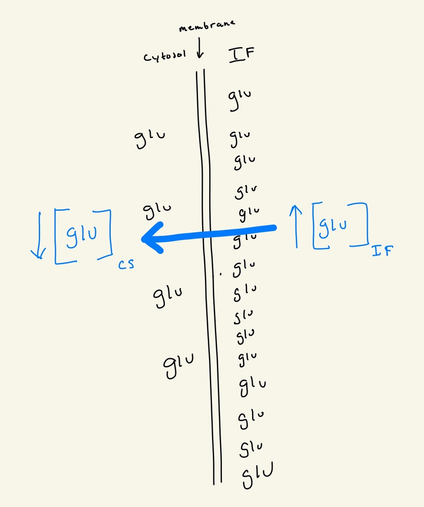

Now, let’s “start” the clock and let the glucose molecules “move”. Let’s pretend that glucose can move only to the left or right. If on the IF side, a glucose that moves to the left will cross the membrane. If it moves to the right it moves away from the membrane. The opposite is true for glucose on the cytosol side of the membrane. We can flip a coin for each glucose to set the direction of movement (then the movement is determined by a random event) with heads = move to the left and tails = move to the right.

Let’s say we get 7 out of 15 (about 50%) heads for the IF glucose, so now 7 of these have cross the membrane to *inside the cell*. And lets say we flip 2 out 4 tails (50%!) for the cs glucose, so two of these cross the membrane to *outside the cell*.

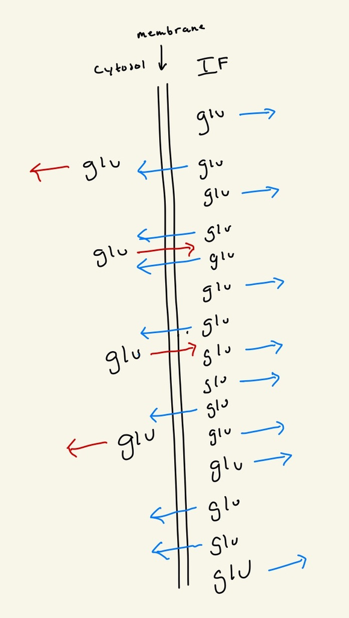

Some things to think about:

1. After this one “step”, the new concentrations are 9 glu/µm on the cytosol side and 10 glu/µm on the IF side, so the gradient (1 glu/µm) is much closer to **equilibrium** (0 glu/µm).
2. individual glucose molecules cross the membrane in both directions.
3. There is a net transport of glucose from outside of the cell to inside of the cell. How could this be if the direction of motion of each glucose is random? There are simply more glucose on the outside than inside of the membrane. So if 50% on the outside move inside and 50$ on the inside move outside, there is a net movement inside. There is nothing magical.
4. Saying “glucose moves inside” can give the misconception that *all* glucose moves inside. This is wrong of course; individual glucose molecules cross the membrane in both directions. This is why I try to say “there is a net transport inside the cell” but sometimes this just takes too long and I say “glucose moves inside”.
5. At equilibrium, glucose doesn’t stop moving – it’s in continuous motions, so continues to cross the membrane in both directions. But, at equilibrium, there is an equal concentration of glucose on either side so the amount crossing inside equals that crossing outside – the meaning of “equilibrium” – so there is no *net* transport.
6. At equilibrium, since there is no net transport, there is no diffusion. Part of the definition of diffusion includes “net transport of a chemical species down its concentration gradient”. At equilibrium, there is no concentration gradient so there is no net transport, so there is no diffusion.
7. Never, ever say anthing like “diffusion happens *in order to reach equilibrium*”. Diffusion doesn’t happen in order to reach equilibrium. This would imply that individual molecules know the system is out of equilibrium and they must move in a certain direction in order to produce equilibrium. Individual particles don’t know anything! Equilibrium is reached for purely statistical reasons.

Think about flipping a coin. If your first flip is heads, is it more likely that your next flip will be tails in order for the frequency of heads to “reach 50%”? Hopefully you answered no because the probability of tails on any and every flip is 50%. But the likelihood that the frequency of heads is not 50% after many millions of flips is extraordinarily tiny.

Humans think teloeologically (that everything has a purpose). In the world that we experience, most behavior that we notice has a purpose and is not due to statistical expectation. If there is a net transport of humans into a classroom, it is not because of an initial concentration gradient of humans and random human movement but because humans *want* to move in to the classroom because an exam is about to begin.

There is no purpose in diffusion. It’s just “entropy happens”.

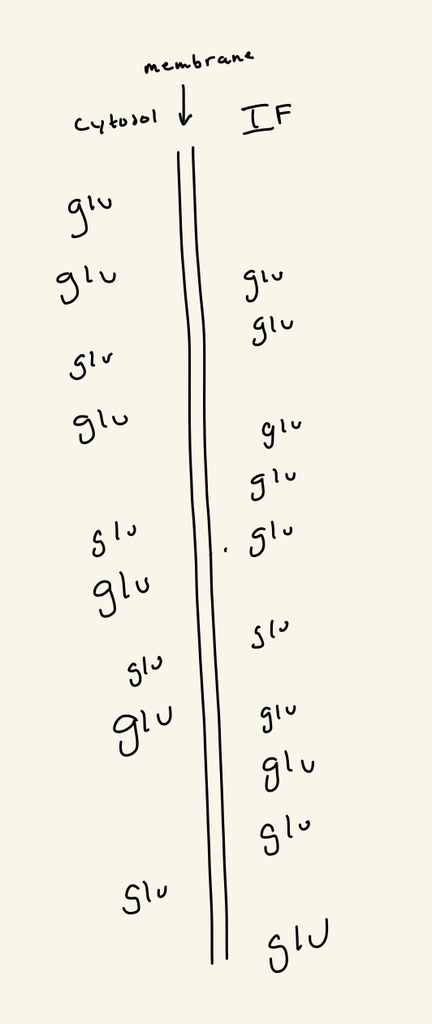